# Correspondence analysis and reciprocal scaling applied to an interaction network

Author

Lisa Nicvert

Published

June 17, 2025

```r
library(here) # path management

# Data wrangling
library(dplyr)
library(tidyr)
library(tibble)
library(stringr)
library(tidytext) # reorder_within
library(effectsize) # Cramer's V

# Ade4
library(ade4)
library(adegraphics)

# Plot
library(ggplot2)
library(patchwork)
library(viridisLite) # Color palette
library(DT) # Display table

# Graph stuff
library(igraph)
library(tidygraph)
library(ggraph)

# Custom package
library(RSnetwork)

set.seed(42)

# Paths ---
figures_path <- here("figures/04_data_analysis")
output_path <- here("outputs/04_data_analysis")
```

## Parameters

```r
paste(names(params), params, sep = ": ")
```

```
[1] "in_folder: ANDEAN_Peru1" "min_freq: 2"
[3] "presabs: FALSE"          "log: FALSE"
[5] "colco: darkred"          "colli: cornflowerblue"
[7] "nf_ca: 3"                "alpha: 0.05"
[9] "selection: LRT"
```

## Prepare data

### Read data

We first read data that was cleaned before (from Dehling et al. (2021)).

```r
#|code-fold: show

in_folder_type <- file.path(here("outputs/01_clean_data"))

in_folder_full <- file.path(in_folder_type,
                            params$in_folder)

interactions_df <- read.csv(file.path(in_folder_full,
                                    "interactions.csv"))
plant_traits <- read.csv(file.path(in_folder_full,
                                   "plant_traits.csv"))
animal_traits <- read.csv(file.path(in_folder_full,
                                    "animal_traits.csv"))
```

### Format data

We remove some redundant traits (`BillLength` and `meanL`).

```r
# Remove "useless" traits
animal_traits <- animal_traits |>
  select(-BillLength)

plant_traits <- plant_traits |>
  select(-meanL)
```

Then, we remove the rows where there are `NA` in the traits.

```r
animal_traits <- animal_traits |>
  drop_na()

plant_traits <- plant_traits |>
  drop_na()

# Keep the table with traits for export
animal_traits_codes <- animal_traits
plant_traits_codes <- plant_traits
```

We format the interaction matrix and remove the column with species names.

```r
#|code-fold: show

interactions_full <- df_to_matrix(interactions_df)

plant_traits <- plant_traits |>
  column_to_rownames("plant_species_code") |>
  select(-plant_species)

animal_traits <- animal_traits |>
  column_to_rownames("animal_species_code") |>
  select(-animal_species)
```

The initial data matrix has 52 rows (plants) and 61 columns (birds).

We remove plant and/or bird species that do not appear in the traits table.

```r
# ---
# Animals
# ---
final_animal_codes <- colnames(interactions_full) %in% rownames(animal_traits)

if (!all(final_animal_codes)) { # If not all final_animal_codes are true
  filtered_out_codes <- colnames(interactions_full)[!final_animal_codes]
  filtered_out_names <- unique(interactions_df$animal_species[interactions_df$animal_species_code %in% filtered_out_codes])

  msg <- paste0(paste(filtered_out_names, filtered_out_codes, sep = " ("), ")")
} else {
  msg <- ""
}

interactions <- interactions_full[ , final_animal_codes]
```

```r
# ---
# Plants
# ---
final_plant_codes <- rownames(interactions) %in% rownames(plant_traits)

if (!all(final_plant_codes)) { # If not all final_animal_codes are true
  filtered_out_codes <- rownames(interactions)[!final_plant_codes]
  filtered_out_names <- unique(interactions_df$plant_species[interactions_df$plant_species_code %in% filtered_out_codes])

  msg <- paste0(paste(filtered_out_names, filtered_out_codes, sep = " ("), ")")
} else {
  msg <- ""
}

interactions <- interactions[final_plant_codes, ]
```

### Filter data

Here we will filter the matrix so that each species interacts with 2 or more other species.

```r
interactions <- filter_matrix(mat = interactions,
                              thr = params$min_freq)
```

```r
animal_traits <- animal_traits[colnames(interactions),]
plant_traits <- plant_traits[rownames(interactions),]
```

`params$presabs` is FALSE so we don’t transform the data to presence-absence.

```r
interactions_orig <- interactions
```

```r
if (params$presabs) {
  interactions <- (interactions != 0)
  interactions <- ifelse(interactions, 1, 0)
  interactions <- as.data.frame(interactions)
}
```

`params$log` is FALSE so we don’t scale the data to log scale.

```r
if (params$log) {
  interactions <- log(interactions + 1)
}
```

Save data in a file:

```r
write.csv(interactions, file = file.path(output_path, "interactions.csv"))
write.csv(animal_traits, file = file.path(output_path, "animal_traits.csv"))
write.csv(plant_traits, file = file.path(output_path, "plant_traits.csv"))
```

### Characterize filtered out species

Let’s explore the profile of the birds/plants that were filtered out compared to the profiles of all birds/plants. Here, we look at the column sums (i.e. the marginal abundance). The aim is to see if the removed species were not only interacting with few species, but also rare.

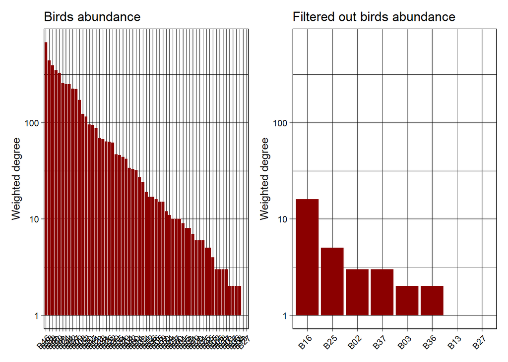

```r
bird_names_out <- colnames(interactions_full)[!(colnames(interactions_full) %in% colnames(interactions))]
bird_deg_out <- colSums(interactions_full[, bird_names_out])

bird_deg_out <- data.frame(degree = bird_deg_out) |>
  rownames_to_column("bird")

gout <- ggplot(bird_deg_out) +
  geom_col(aes(x = reorder(bird, -degree), y = degree),
           fill = params$colco) +
  theme_linedraw() +
  theme(axis.text.x = element_text(angle = 45, hjust = 1)) +
  ggtitle("Filtered out birds abundance")

bird_deg_full <- colSums(interactions_full)

bird_deg_full <- data.frame(degree = bird_deg_full) |>
  rownames_to_column("bird")

gall <- ggplot(bird_deg_full) +
  geom_col(aes(x = reorder(bird, -degree), y = degree),
           fill = params$colco) +
  theme_linedraw() +
  theme(axis.text.x = element_text(angle = 45, hjust = 1)) +
  ggtitle("Birds abundance")

gall + gout &
  scale_y_log10(limits = c(1, max(bird_deg_full$degree))) &
  ylab("Weighted degree") &
  theme(axis.title.x = element_blank())
```

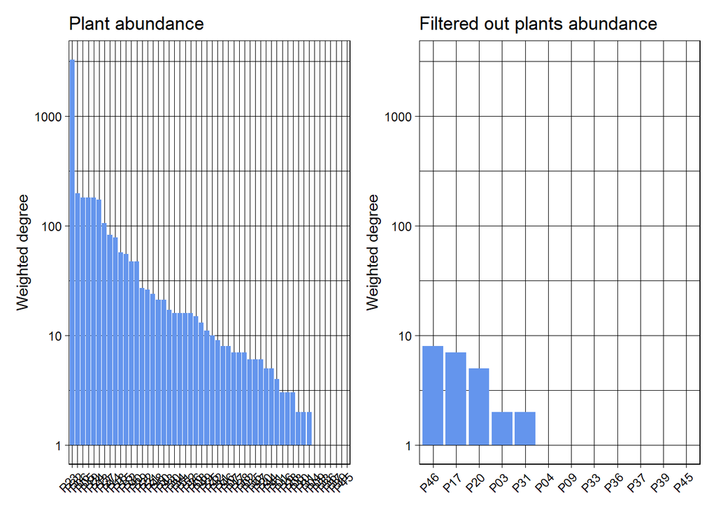

```r
plant_names_out <- rownames(interactions_full)[!(rownames(interactions_full) %in% rownames(interactions))]
plant_deg_out <- rowSums(interactions_full[plant_names_out, ])

plant_deg_out <- data.frame(degree = plant_deg_out) |>
  rownames_to_column("plant")

gout <- ggplot(plant_deg_out) +
  geom_col(aes(x = reorder(plant, -degree), y = degree),
           fill = params$colli) +
  theme_linedraw() +
  theme(axis.text.x = element_text(angle = 45, hjust = 1)) +
  ggtitle("Filtered out plants abundance")

plant_deg_full <- rowSums(interactions_full)

plant_deg_full <- data.frame(degree = plant_deg_full) |>
  rownames_to_column("plant")

gall <- ggplot(plant_deg_full) +
  geom_col(aes(x = reorder(plant, -degree), y = degree),
           fill = params$colli) +
  theme_linedraw() +
  theme(axis.text.x = element_text(angle = 45, hjust = 1)) +
  ggtitle("Plant abundance")

gall + gout  & scale_y_log10(limits = c(1, max(plant_deg_full$degree))) &
  ylab("Weighted degree") &
  theme(axis.title.x = element_blank())
```

### Display data

The matrix we will analyze has 40 rows (plants) and 53 columns (birds).

Here is the original data matrix:

```r
interactions_df <- matrix_to_df(interactions, colnames = "birds")

interactions_df_points <- interactions_df |>
    filter(value != 0)
```

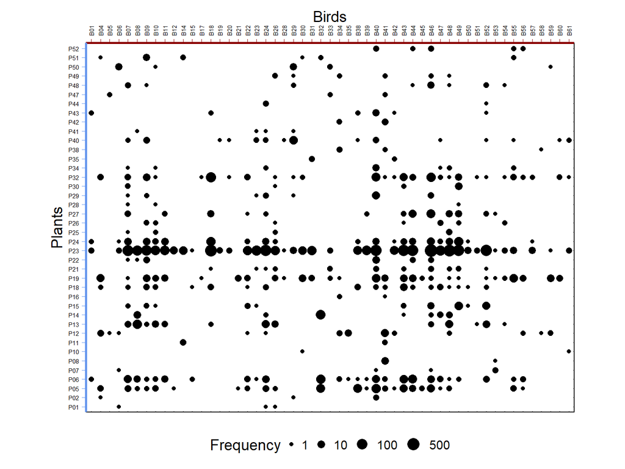

```r
if(params$log) {
  msize <- max(interactions)*0.7
} else {
  msize <- max(interactions)*0.01
}

breaks <- c(1, 10, 100, 500)

txtsize <- 14

# Visualize filtered matrix
plot_matrix(interactions,
            legend_title = ifelse(params$log,
                                  "ln(frequency)", "Frequency"),
            max_size = msize,
            base_size = txtsize,
            breaks = breaks,
            trans = "log1p",
            xlab = "Birds") +
  theme(legend.key.width = unit(0.1, 'cm'),
        axis.line.x.top = element_line(colour = params$colco,
                                       linewidth = 1),
        axis.ticks.x.top = element_line(colour = params$colco),
        axis.line.y = element_line(colour = params$colli,
                                   linewidth = 1),
        axis.text = element_text(size = txtsize*0.4),
        axis.ticks.y = element_line(colour = params$colli))
```

```r
# Export plot
ggsave(file.path(figures_path, "matrix.jpeg"),
       width = 14, height = 12,
       dpi = 600, units = "cm", bg = "white")
```

```r
# Create graph object
g <- graph_from_biadjacency_matrix(interactions, weighted = TRUE)

gtbl <- as_tbl_graph(g) |>
  activate(nodes) |>
  mutate(type = ifelse(type, "bird", "plant"))

nodes <- V(g)

# Reorder nodes as the original table
co_reordered <- unname(rank(nodes[colnames(interactions)]))
li_reordered <- unname(rank(nodes[rownames(interactions)]))

# Create centered coordinates
co_y <- scale(co_reordered, center = TRUE,
              scale = FALSE)
li_y <- scale(li_reordered, center = TRUE,
              scale = FALSE)

y <- cbind(c(li_y, co_y))
x <- rep(c(0, 1), c(length(li_y), length(co_y)))
lay <- data.frame(x, y)
```

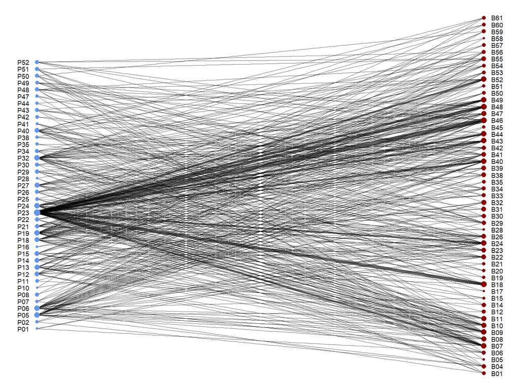

```r
gtbl <- gtbl |>
  mutate(degree = centrality_degree(weights = weight))

ggraph(gtbl, layout = lay) +
  geom_edge_fan(aes(width = weight),
                alpha = 0.6,
                show.legend = FALSE) +
  scale_edge_width(range = c(.2, 2.5)) +
  scale_color_manual(values = c(params$colco, params$colli)) +
  geom_node_point(aes(col = type, size = degree),
                  show.legend = FALSE) +
  scale_size_area(max_size = 3, trans = "log") +
  geom_node_text(aes(label = name),
                 show.legend = FALSE,
                 size = 2.5,
                 nudge_x = c(rep(-0.03, nrow(interactions)),
                             rep(0.03, ncol(interactions)))) +
  theme_void()
```

## Names and codes

Below are the correspondences between species codes and their names:

|  | Code | Species name | Fruit diameter (mm) | Plant height (m) | Crop mass (g) |
| --- | --- | --- | --- | --- | --- |
| 1 | P01 | Anthurium obtusum | 2.9 | 5 | 0.8 |
| 2 | P02 | Banara arguta | 9 | 5.2 | 241.5 |
| 3 | P05 | Cecropia polystachya | 20.4 | 13 | 6813.4 |
| 4 | P06 | Cecropia strigosa | 9.2 | 12.1 | 3813.1 |
| 5 | P07 | Cestrum parqui | 5.9 | 3.9 | 470.8 |
| 6 | P08 | Cestrum stipulatum | 6.9 | 4 | 225 |
| 7 | P10 | Croton rusbyi | 6.5 | 6.8 | 7.2 |
| 8 | P11 | Elaeagia mariae | 2.8 | 9.8 | 22.4 |
| 9 | P12 | Endlicheria sp | 12.3 | 13.8 | 3986.1 |
| 10 | P13 | Ficus americana | 3.7 | 15 | 606.7 |

[output cut: 30 more lines]

|  | Code | Species name | Kipp's index | Bill width (mm) | Body mass (g) |
| --- | --- | --- | --- | --- | --- |
| 1 | B01 | Anisognathus somptuosus | 0.19 | 10.6 | 42 |
| 2 | B04 | Catharus ustulatus | 0.32 | 9.5 | 30.3 |
| 3 | B05 | Cephalopterus ornatus | 0.17 | 30.2 | 380 |
| 4 | B06 | Chiroxiphia boliviana | 0.16 | 9.2 | 17.2 |
| 5 | B07 | Chlorochrysa calliparaea | 0.24 | 7.5 | 17 |
| 6 | B08 | Chlorophonia cyanea | 0.28 | 6.5 | 14 |
| 7 | B09 | Chlorospingus flavigularis | 0.17 | 10.1 | 25.6 |
| 8 | B10 | Chlorospingus ophthalmicus | 0.16 | 7.7 | 15.7 |
| 9 | B11 | Chlorospingus parvirostris | 0.16 | 8.5 | 24 |
| 10 | B12 | Colaptes rubiginosus | 0.23 | 11.2 | 65.4 |

[output cut: 43 more lines]

```r
# Transform for LateX

# Italicize
codes_plants$`Species name` <- paste0("\\textit{", codes_plants$`Species name`, "}")
codes_animals$`Species name` <- paste0("\\textit{", codes_animals$`Species name`, "}")

# Add newline character
codes_plants[, ncol(codes_plants)] <- paste0(codes_plants[, ncol(codes_plants)], "\\\\")
colnames(codes_plants)[ncol(codes_plants)] <- paste0(colnames(codes_plants)[ncol(codes_plants)], "\\\\")

codes_animals[, ncol(codes_animals)] <- paste0(codes_animals[, ncol(codes_animals)], "\\\\")
colnames(codes_animals)[ncol(codes_animals)] <- paste0(colnames(codes_animals)[ncol(codes_animals)], "\\\\")
```

```r
write.table(codes_plants,
            file = file.path(output_path, "codes_plants.csv"),
            quote = FALSE,
            sep = " & ",
            row.names = FALSE)
write.table(codes_animals,
            file = file.path(output_path, "codes_animals.csv"),
            quote = FALSE,
            sep = " & ",
            row.names = FALSE)
```

## Correspondence analysis

Let’s first perform a chi-squared test to check if there is structure in the data.

```r
(chsq <- chisq.test(interactions, simulate.p.value = TRUE))
```

```
    Pearson's Chi-squared test with simulated p-value (based on 2000
    replicates)

data:  interactions
X-squared = 17784, df = NA, p-value = 0.0004998
```

```r
(V <- cramers_v(interactions))
```

```
Cramer's V (adj.) |       95% CI
--------------------------------
0.29              | [0.26, 1.00]

- One-sided CIs: upper bound fixed at [1.00].
```

The p-value is 5^{-4}.

Now let’s perform CA. For this analysis, we will keep 3 axes.

```r
ca <- dudi.coa(interactions,
                scannf = FALSE,
                nf = params$nf_ca)
```

CA eigenvalues and square root of eigenvalues:

```r
# Eigenvalues
ca$eig
```

```
 [1] 6.191934e-01 4.167874e-01 3.928879e-01 3.039191e-01 2.773904e-01
 [6] 2.581142e-01 1.784613e-01 1.448607e-01 1.294030e-01 1.157875e-01
[11] 1.027157e-01 8.850992e-02 8.342531e-02 6.946602e-02 5.637214e-02
[16] 4.874483e-02 4.126778e-02 3.824801e-02 3.333744e-02 3.185438e-02
[21] 2.555155e-02 2.300389e-02 2.218657e-02 2.084826e-02 1.716005e-02
[26] 1.435705e-02 1.262480e-02 1.193993e-02 7.404297e-03 5.325839e-03
[31] 4.704812e-03 3.494085e-03 2.855760e-03 2.200572e-03 1.676954e-03
[36] 9.899936e-04 6.284900e-04 3.436072e-04 1.314759e-07
```

```r
# Square roots of eigenvalues
sqrt(ca$eig)
```

```
 [1] 0.7868884498 0.6455907415 0.6268077170 0.5512885639 0.5266786274
 [6] 0.5080493838 0.4224467983 0.3806057051 0.3597263539 0.3402755650
[11] 0.3204929191 0.2975061708 0.2888343968 0.2635640656 0.2374281810
[16] 0.2207823099 0.2031447240 0.1955709726 0.1825854443 0.1784779585
[21] 0.1598485306 0.1516703401 0.1489515770 0.1443892510 0.1309963771
[26] 0.1198209041 0.1123601228 0.1092700031 0.0860482228 0.0729783458
[31] 0.0685916339 0.0591107831 0.0534393144 0.0469102545 0.0409506254
[36] 0.0314641633 0.0250697037 0.0185366457 0.0003625961
```

Below are the corresponding eigenvalues graphs:

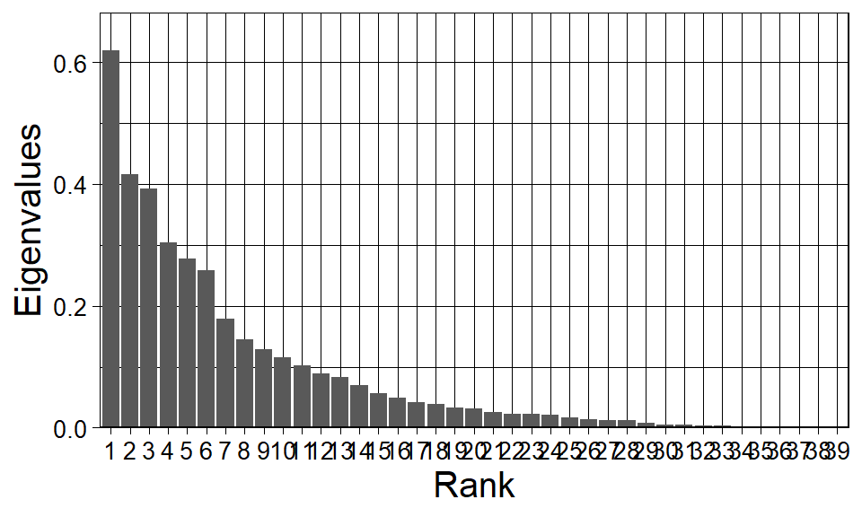

```r
plot_eig(ca$eig, showrank = TRUE) +
  ylab("Eigenvalues") +
  theme(axis.title = element_text(size = 15),
        axis.text = element_text(size = 10))
```

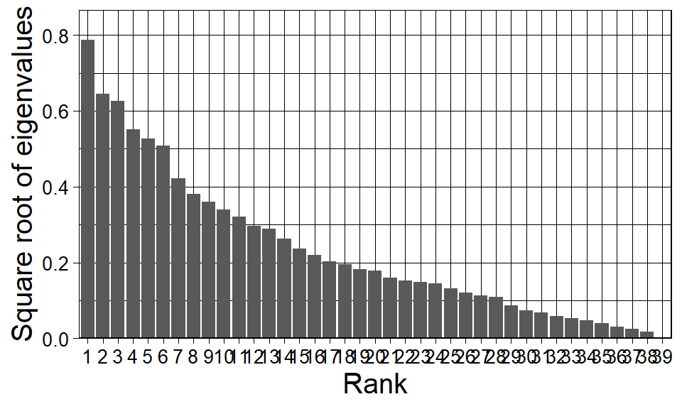

```r
# ggsave(file.path(figures_path, "eig.png"),
#        width = 7, height = 4.5, dpi = 300)

plot_eig(sqrt(ca$eig), showrank = TRUE) +
  ylab("Square root of eigenvalues") +
  theme(axis.title = element_text(size = 15),
        axis.text = element_text(size = 10))
```

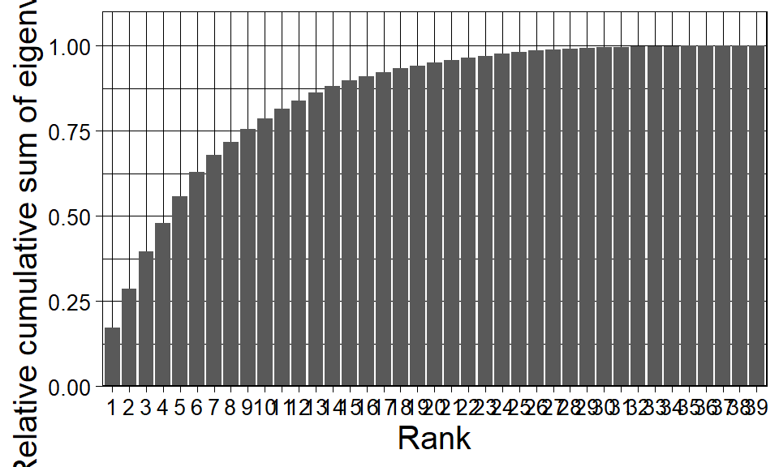

```r
ggsave(file.path(figures_path, "sqeig.png"),
       width = 7, height = 4.5, dpi = 300)

plot_eig(cumsum(ca$eig)/sum(ca$eig), showrank = TRUE) +
  ylab("Relative cumulative sum of eigenvalues") +
  theme(axis.title = element_text(size = 15),
        axis.text = element_text(size = 10))
```

```r
ggsave(file.path(figures_path, "cumsumeig.png"),
       width = 7, height = 4.5, dpi = 300)
```

Below is the interaction matrix reordered with the first axis of the CA:

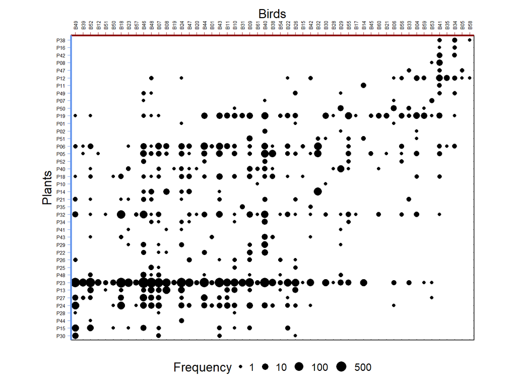

```r
interactions_reordered <- interactions[order(ca$li[, 1]),
                                       order(ca$co[, 1])]

plot_matrix(interactions_reordered,
            legend_title = ifelse(params$log,
                                  "ln(frequency)", "Frequency"),
            max_size = msize,
            base_size = txtsize,
            breaks = breaks,
            trans = "log1p",
            xlab = "Birds") +
  theme(legend.key.width = unit(0.1, 'cm'),
        axis.line.x.top = element_line(colour = params$colco,
                                       linewidth = 1),
        axis.ticks.x.top = element_line(colour = params$colco),
        axis.line.y = element_line(colour = params$colli,
                                   linewidth = 1),
        axis.text = element_text(size = txtsize*0.4),
        axis.ticks.y = element_line(colour = params$colli))
```

```r
# Export plot
ggsave(file.path(figures_path, "matrix_reordered.jpeg"),
       width = 14, height = 12,
       dpi = 600, units = "cm", bg = "white")
```

```r
# Reorder CA coordinates as the graph nodes
co_reordered <- ca$co[nodes, 1]
co_reordered <- co_reordered[!is.na(co_reordered)]

li_reordered <- ca$li[nodes, 1]
li_reordered <- li_reordered[!is.na(li_reordered)]

# Get the ranks
co_rank <- rank(ca$co[,1])
li_rank <- rank(li_reordered)

# Transformto centered coordinates
co_y <- scale(co_rank, center = TRUE,
              scale = FALSE)
li_y <- scale(li_rank, center = TRUE,
              scale = FALSE)

y2 <- cbind(c(li_y, co_y))

lay2 <- lay |>
  mutate(y = y2)
```

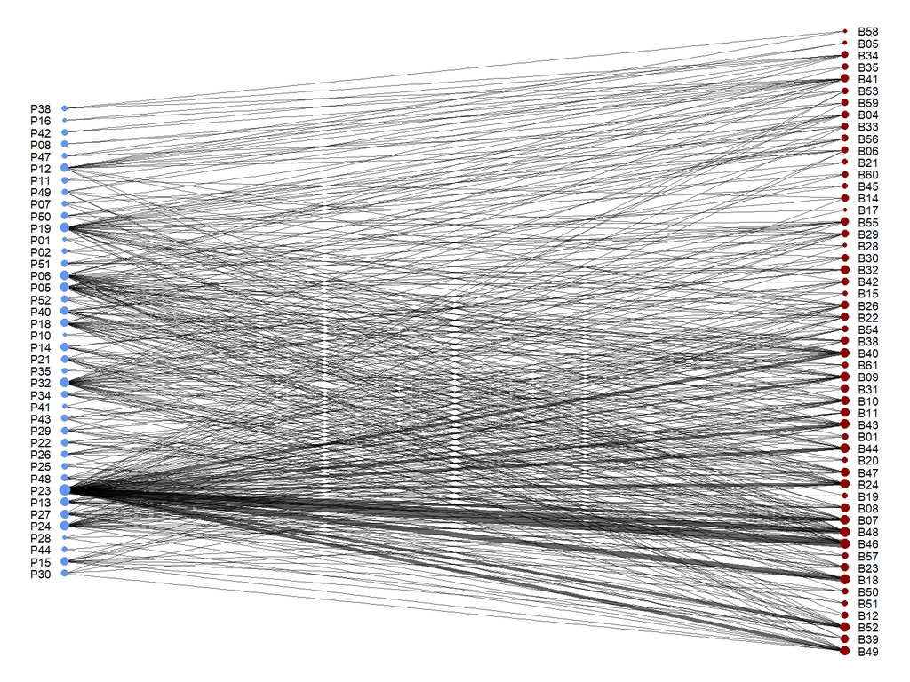

```r
ggraph(gtbl, layout = lay2) +
  geom_edge_fan(aes(width = weight),
                alpha = 0.6,
                show.legend = FALSE) +
  scale_edge_width(range = c(.2, 2.5)) +
  scale_color_manual(values = c(params$colco, params$colli)) +
  geom_node_point(aes(col = type, size = degree),
                  show.legend = FALSE) +
  scale_size_area(max_size = 3, trans = "log") +
  geom_node_text(aes(label = name),
                 show.legend = FALSE,
                 size = 2.5,
                 nudge_x = c(rep(-0.03, nrow(interactions)),
                             rep(0.03, ncol(interactions)))) +
  theme_void()
```

We can also rearrange the interaction matrix to highlight nestedless. For that, we arrange by decreasing weighted degree:

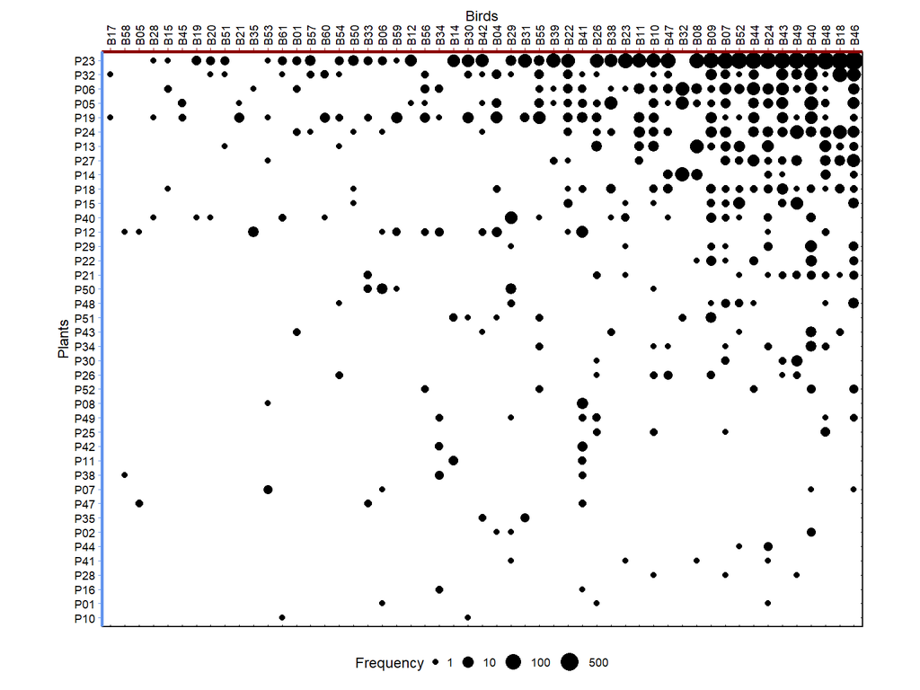

```r
interactions_nested <- interactions[order(rowSums(interactions)),
                                    order(colSums(interactions))]

plot_matrix(interactions_nested,
            legend_title = ifelse(params$log,
                                  "ln(frequency)", "Frequency"),
            max_size = msize,
            base_size = 9,
            breaks = breaks,
            trans = "log1p",
            xlab = "Birds") +
  theme(legend.key.width = unit(0.1, 'cm'),
        axis.line.x.top = element_line(colour = params$colco,
                                       linewidth = 1),
        axis.ticks.x.top = element_line(colour = params$colco),
        axis.line.y = element_line(colour = params$colli,
                                   linewidth = 1),
        axis.ticks.y = element_line(colour = params$colli))
```

We can visualize the coordinates ordered along the axes and scan for gaps (as advised by Dam et al. (2021)):

```r
li_coord <- ca$li |>
  rownames_to_column("plant")

li_coord <- li_coord |>
  pivot_longer(cols = 2:ncol(li_coord),
               names_to = "axis")

gli <- ggplot(li_coord) +
  geom_point(aes(x = reorder_within(plant, by = value, within = axis,
                                    decreasing = TRUE),
                 y = value, group = axis),
             col = params$colli) +
  xlab("Plants")
```

```r
co_coord <- ca$co |>
  rownames_to_column("bird")

co_coord <- co_coord |>
  pivot_longer(cols = 2:ncol(co_coord),
               names_to = "axis") |>
  mutate(axis = str_replace(axis, "Comp", "Axis"))

gco <- ggplot(co_coord) +
  geom_point(aes(x = reorder_within(bird, by = value, within = axis,
                                    decreasing = TRUE),
                 y = value, group = axis),
             col = params$colco) +
  xlab("Birds")
```

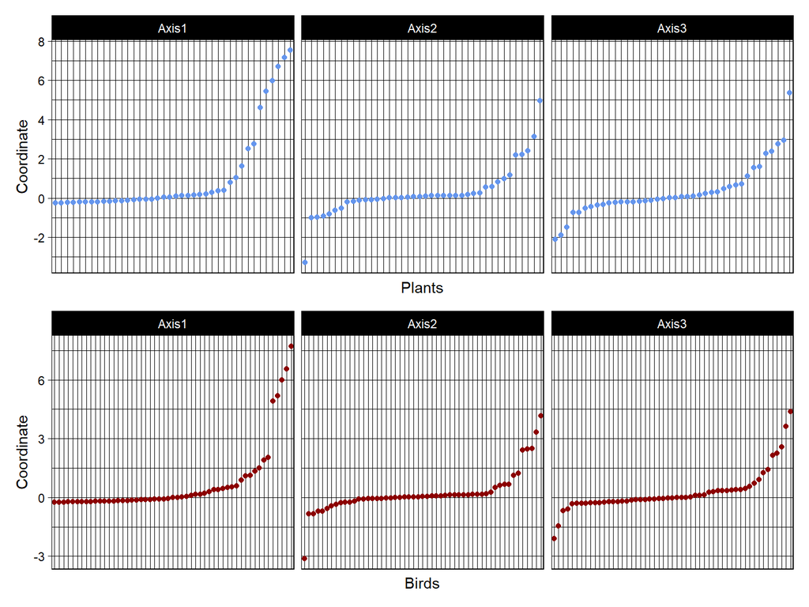

```r
gli / gco  &
  facet_grid(cols = vars(axis), scales = "free") &
  ylab("Coordinate") &
  theme_linedraw() &
  theme(axis.text.x = element_blank(),
        axis.ticks.x = element_blank())
```

To plot the results in a biplot, there are two scalings available. They are depicted below.

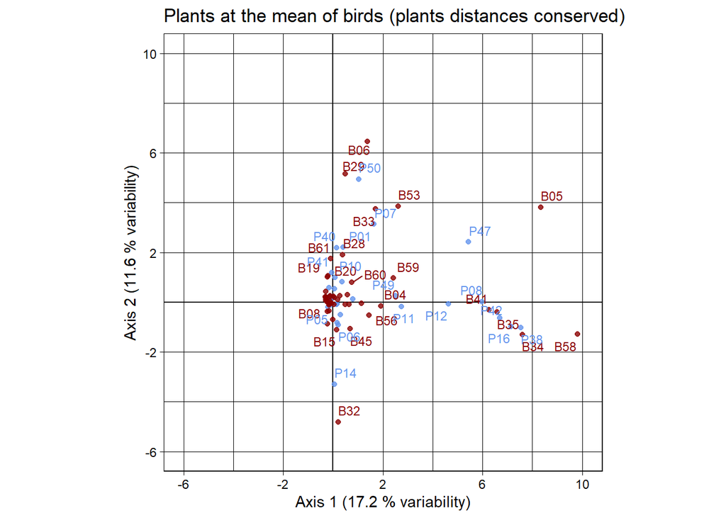

```r
xlim <- c(-6, 10)
ylim <- c(-6, 10)
multiplot(indiv_row = ca$li, indiv_col = ca$c1,
          row_color = params$colli, col_color = params$colco, eig = ca$eig,
          max.overlaps = 20,
          xlim = xlim, ylim = ylim,
          title = "Plants at the mean of birds (plants distances conserved)")
```

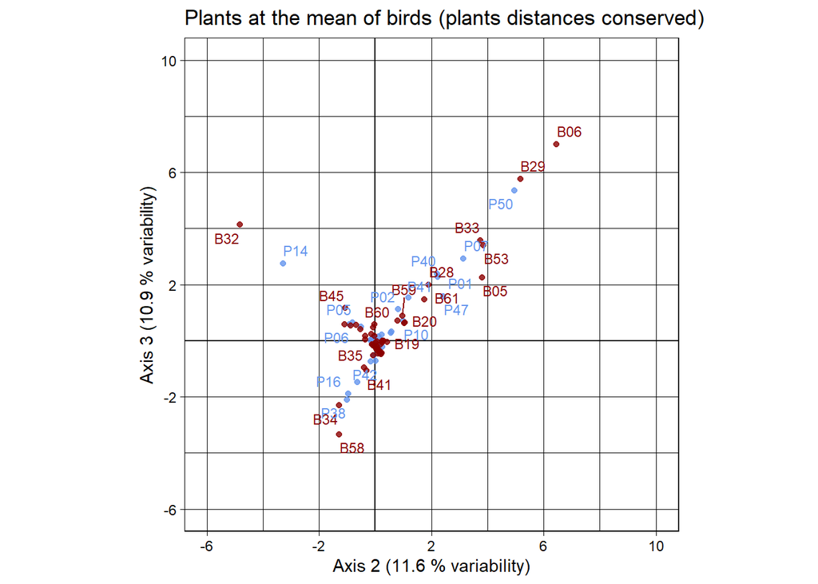

```r
multiplot(indiv_row = ca$li, indiv_col = ca$c1,
          x = 2, y = 3,
          row_color = params$colli, col_color = params$colco, eig = ca$eig,
          max.overlaps = 20,
          xlim = xlim, ylim = ylim,
          title = "Plants at the mean of birds (plants distances conserved)")
```

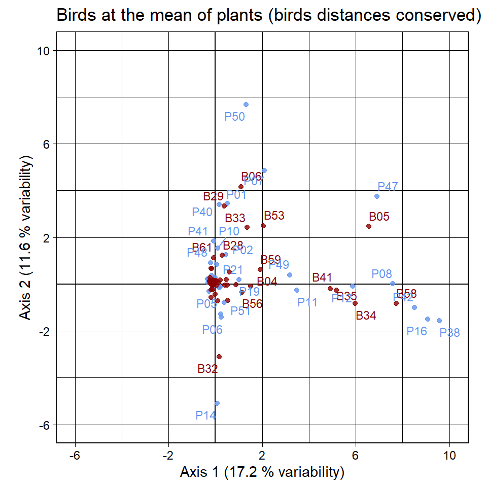

```r
xlim <- c(-6, 10)
ylim <- c(-6, 10)

multiplot(indiv_row = ca$l1, indiv_col = ca$co,
          row_color = params$colli, col_color = params$colco, eig = ca$eig,
          xlim = xlim, ylim = ylim,
          title = "Birds at the mean of plants (birds distances conserved)")
```

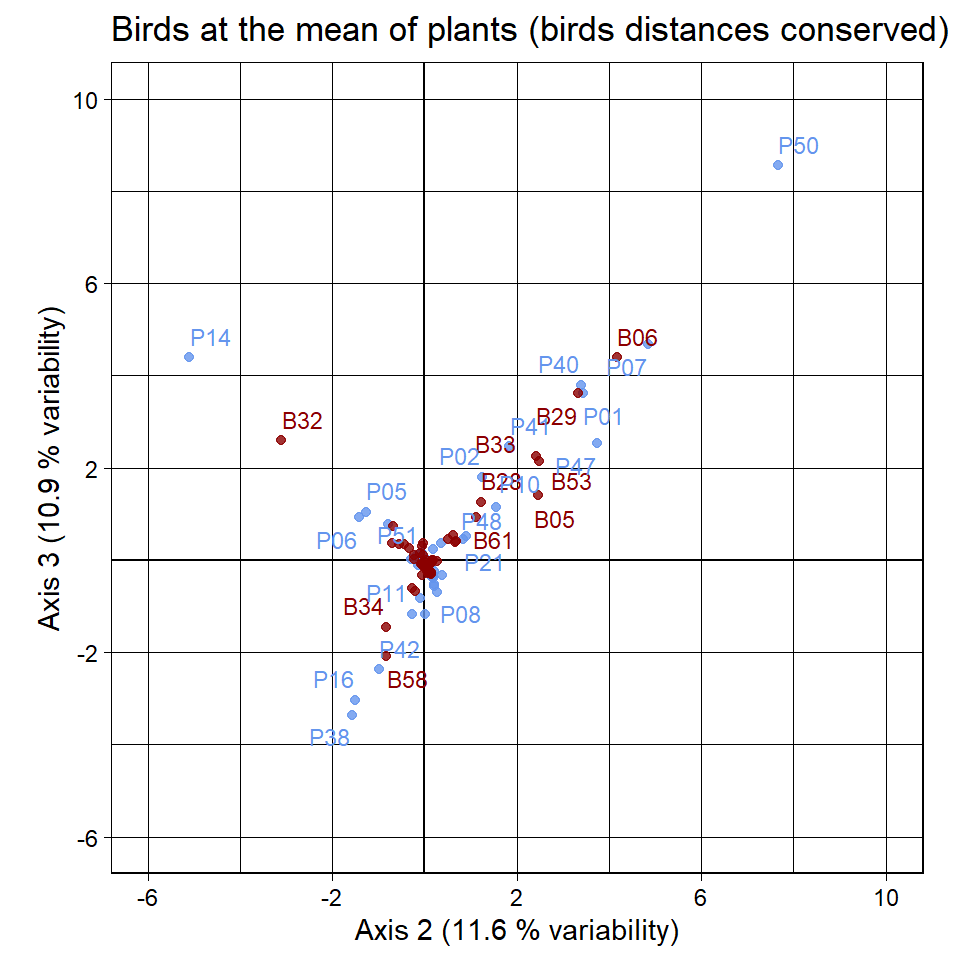

```r
multiplot(indiv_row = ca$l1, indiv_col = ca$co,
          x = 2, y = 3,
          xlim = xlim, ylim = ylim,
          row_color = params$colli, col_color = params$colco, eig = ca$eig,
          title = "Birds at the mean of plants (birds distances conserved)")
```

## Reciprocal scaling

We will now perform reciprocal scaling (Thioulouse and Chessel 1992).

```r
recscal <- reciprocal.coa(ca)
```

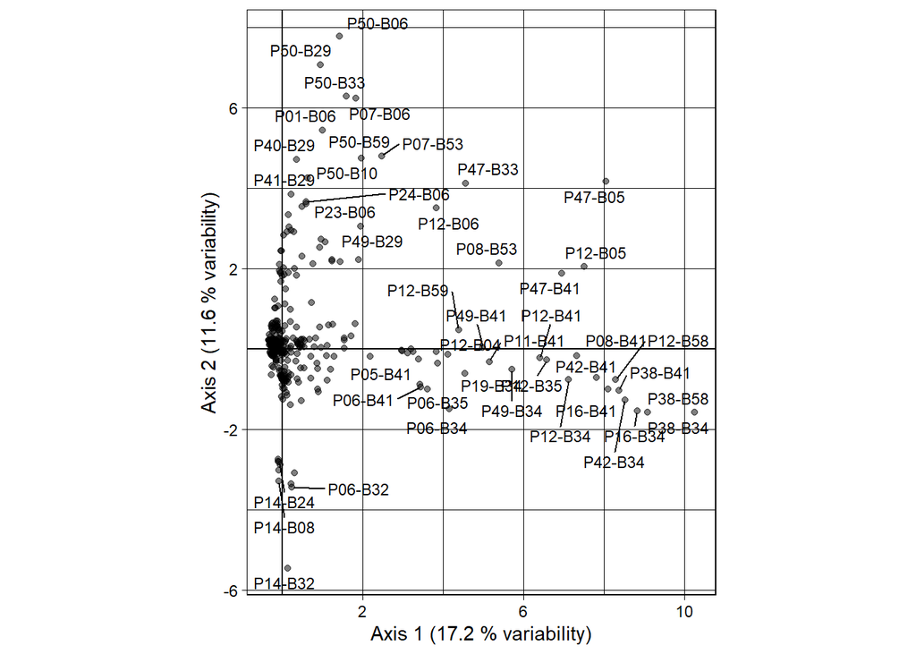

```r
multiplot(indiv_row = recscal,
          indiv_row_lab = paste(recscal$Row, recscal$Col, sep = "-"),
          eig = ca$eig,
          alphapoints = 0.5)
```

This graph shows the correspondences of species interactions in the multivariate space. The correspondences are related to the CA coordinates as follows (Thioulouse and Chessel 1992):

$$h_k(i, j) = \frac{u^\star_{ik} + v^\star_{jk}}{\sqrt{2 \lambda_k \mu_k}}$$

To put it differently, each correspondence is at the “mean” position between the `li`($L_k(i)$) and the `co` (scaled with a scaling factor).

The standard deviations for plant species $i$ is (Thioulouse and Chessel 1992):

$$s_{ik} = \sqrt{\frac{1}{2\lambda_k\mu_k} \left( \frac{1}{y_{i \cdot}} \sum_{j = 1}^c \left(y_{ij} {v^\star_{jk}}^2 \right) - \lambda_k {u^\star_{ik}}^2 \right)}$$

And the standard deviations for bird species $j$ is (Thioulouse and Chessel 1992):

$$s_{jk} = \sqrt{\frac{1}{2\lambda_k\mu_k} \left( \frac{1}{y_{\cdot j}} \sum_{i = 1}^r \left(y_{ij} {u^\star_{ik}}^2 \right) - \lambda_k {v^\star_{jk}}^2 \right)}$$
NB: these standard deviations can also be computed directly as the standard deviations of the $h_k(i, j)$.

The graphs below show plants and birds interaction niches in the multivariate space.

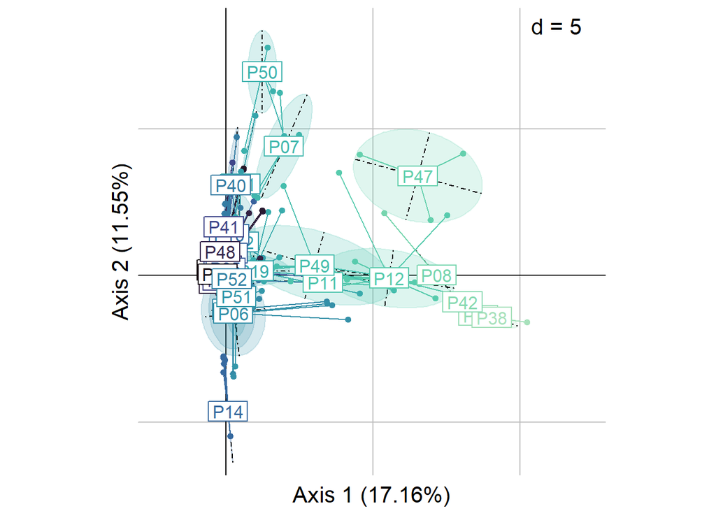

```r
# Create viridis palette for rows
colrow <- viridis(nrow(interactions), option = "G", end = 0.9)

# Order palette so that colors match position on axis 1
colrow <- colrow[rank(ca$li[[1]])]

txtsize <- 1.3
# png(file.path(figures_path, "plant_ell.png"),
#     bg = "white",
#     res = 600,
#     width = 15, height = 15, units = "cm")
plot_reciprocal(recscal = recscal,
                dudi = ca,
                col = colrow,
                labsize = txtsize*0.8,
                pgrid.text.cex = txtsize,
                xlab.cex = txtsize,
                ylab.cex = txtsize,
                group = "li",
                xax = 1, yax = 2)
```

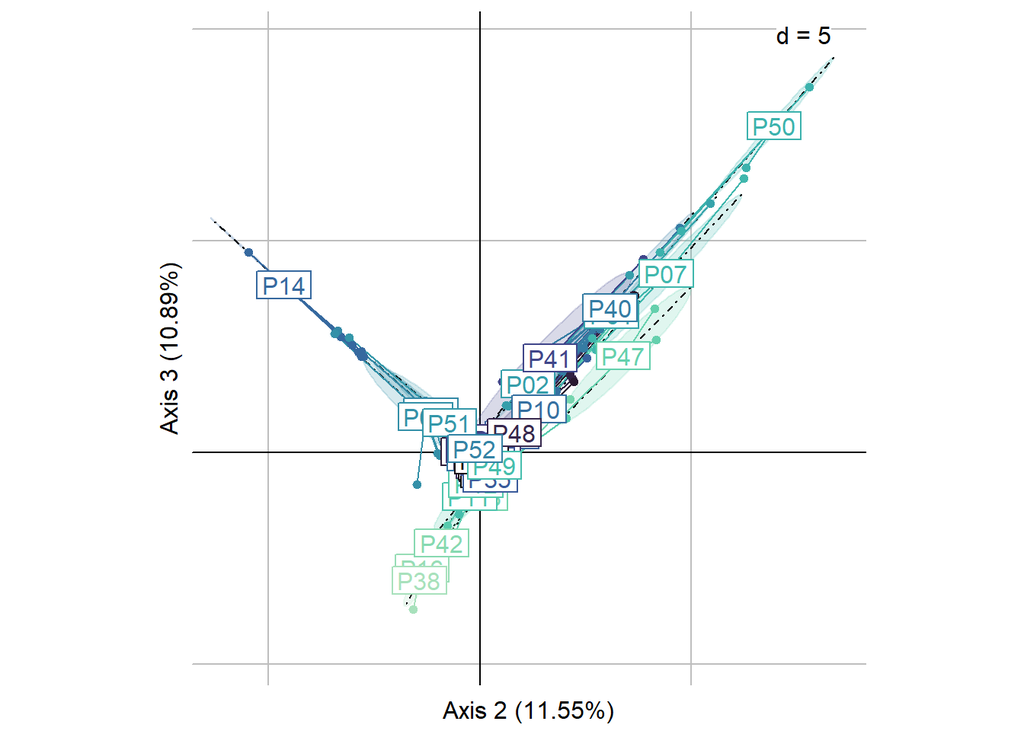

```r
# dev.off()

plot_reciprocal(recscal = recscal,
                dudi = ca,
                col = colrow,
                group = "li",
                xax = 2, yax = 3)
```

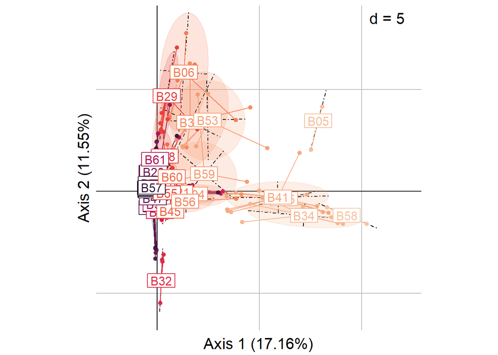

```r
# Create viridis palette for columns
colco <- viridis(ncol(interactions), option = "F", end = 0.9)

# Order palette so that colors match position on axis 1
colco <- colco[rank(ca$co[[1]])]

# png(file.path(figures_path, "birds_ell.png"),
#     bg = "white",
#     res = 600,
#     width = 15, height = 15, units = "cm")
plot_reciprocal(recscal = recscal,
                dudi = ca,
                col = colco,
                labsize = txtsize*0.8,
                pgrid.text.cex = txtsize,
                xlab.cex = txtsize,
                ylab.cex = txtsize,
                group = "co",
                xax = 1, yax = 2)
```

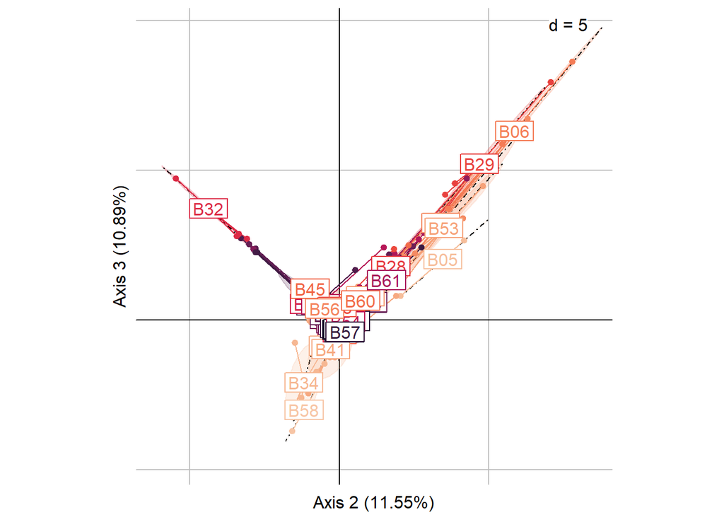

```r
# dev.off()

plot_reciprocal(recscal = recscal,
                dudi = ca,
                group = "co",
                xax = 2, yax = 3,
                col = colco)
```

## Linear model

Here we try to model niche width as a function of the position in the axes of the multivariate analysis.

A linear model is also constructed and chosen as the best model between
$$s_k = a~m_k + c$$
and
$$s_k = a~m_k + b~m_k^2 + c$$

```r
ts <- 2.5 # labels size
ps <- 1 # points size

ax <- 1:3

lmplots <- list()

gbirds2 <- list()
gplants2 <- list()

lmbirds <- vector(mode = "list", length = length(ax))
names(lmbirds) <- paste0("ax", ax, "_birds")

lmplants <- vector(mode = "list", length = length(ax))
names(lmplants) <- paste0("ax", ax, "_plants")

msd <- get_mean_sd(recscal, ax = 1:params$nf_ca)
```

```r
for(a in ax){
  # Get the dataframes with mean/standard deviation for a given axis
  msd_birds <- data.frame(birds = rownames(msd$colsd),
                          mean = msd$colmean[, a],
                          sd = msd$colsd[, a])
  msd_plants <- data.frame(plants = rownames(msd$rowsd),
                           mean = msd$rowmean[, a],
                           sd = msd$rowsd[, a])

  # Linear models for birds ---
  # Construct models
  lmsimple <- lm(sd ~ mean, msd_birds)
  lm2 <- lm(sd ~ mean + I(mean^2), msd_birds)

  # Get best model for birds
  lmb <- get_best_model(lmsimple, lm2, alpha = params$alpha)

  lab_birds <- lm_labels(lmb, a)

  # Get predictions
  pred <- "confidence"
  birds_pred <- get_pred(dat_predict = msd_birds$mean, lmb,
                         interval = pred, level = 1 - params$alpha)

  # Linear models for plants ---
  # Construct models
  lmsimple <- lm(sd ~ mean, msd_plants)
  lm2 <- lm(sd ~ mean + I(mean^2), msd_plants)

  # Get best model for plants
  lmp <- get_best_model(lmsimple, lm2, alpha = params$alpha)

  lab_plants <- lm_labels(lmp, a)

  # Get predictions
  plants_pred <- get_pred(dat_predict = msd_plants$mean, lmp,
                          interval = pred, level = 1 - params$alpha)

  # Merge datasets ---
  msd_plants <- msd_plants |>
    rename("species" = "plants") |>
    mutate(type = "Plants")
  msd_birds <- msd_birds |>
    rename("species" = "birds") |>
    mutate(type = "Birds")
  msd_merge <- rbind(msd_plants, msd_birds)

  plants_pred <- plants_pred |>
    mutate(type = "Plants")
  birds_pred <- birds_pred |>
    mutate(type = "Birds")
  pred <- rbind(plants_pred, birds_pred)

  lab_df <- rbind(lab_birds, lab_plants)
  lab_df$type <- c("Birds", "Plants")

  # Plots sd versus mean ---
  lmplots[[a]] <- plot_lm_mean_sd(msd_merge,
                                  dat_pred = pred,
                                  text_size = ts,
                                  points_size = ps,
                                  nudge_x = 0.1,
                                  col = c(params$colco, params$colli),
                                  lab = lab_df,
                                  seed = 123,
                                  ylab = paste0("Niche breadth\n(standard deviation on axis ", a, ")"),
                                  xlab = paste0("Latent trait (mean position on axis ", a, ")"),
                                  facet = "type")

  lmbirds[[a]] <- lmb
  lmplants[[a]] <- lmp

  # Plot sd versus number of interactions ---
  gb2 <- ggplot() +
    geom_point(aes(y = msd_birds$sd, x = colSums(interactions != 0)),
               col = params$colco, alpha = 0.5) +
    theme_linedraw() +
    ggtitle(paste("Bird niche width versus number of interacting partners on axis", a)) +
    xlim(c(0, max(colSums(interactions != 0))))

  gp2 <- ggplot() +
    geom_point(aes(y = msd_plants$sd, x = rowSums(interactions != 0)),
               col = params$colli, alpha = 0.5) +
    theme_linedraw() +
    ggtitle(paste("Plant niche width versus number of interacting partners on axis", a)) +
    xlim(c(0, max(rowSums(interactions != 0))))

  # gbirds2 <- c(gbirds2, list(gb2))
  gplants2 <- c(gplants2, list(gp2))

}
```

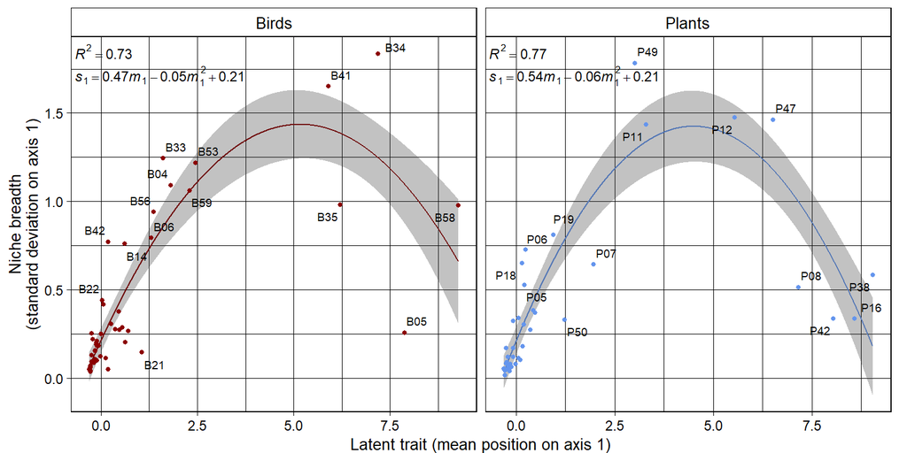

```r
lmplots[[1]] +
  theme(plot.margin = margin(5, 10, 0, 5))
```

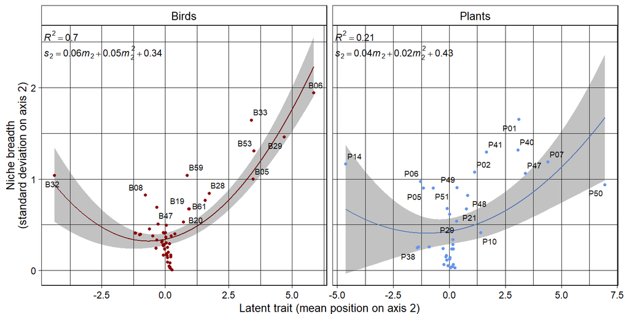

```r
# Export plot
ggsave(file.path(figures_path, "lm_ax1.jpeg"),
       width = 18, height = 8,
       dpi = 600, units = "cm", bg = "white")

lmplots[[2]] +
  theme(plot.margin = margin(5, 10, 0, 5),
        text = element_text(size = ts*3.5))
```

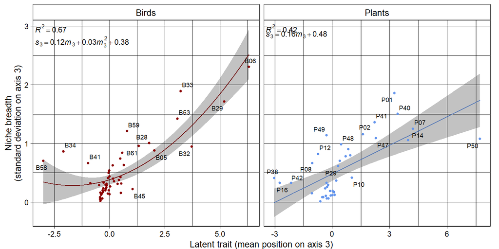

```r
# Export plot
ggsave(file.path(figures_path, "lm_ax2.jpeg"),
       width = 18, height = 8,
       dpi = 600, units = "cm", bg = "white")

lmplots[[3]] +
  theme(plot.margin = margin(5, 10, 0, 5),
        text = element_text(size = ts*3.5))
```

## Relationship with traits

In order to interpret the axes, we can compute the correlations between the traits tables and the coordinates of birds/plants on each axis.

```r
corli <- cor(ca$li, plant_traits)
corli <- t(corli)
```

```r
corco <- cor(ca$co, animal_traits)
corco <- t(corco)
```

Below is the a posteriori correlation circle between the axes and the traits:

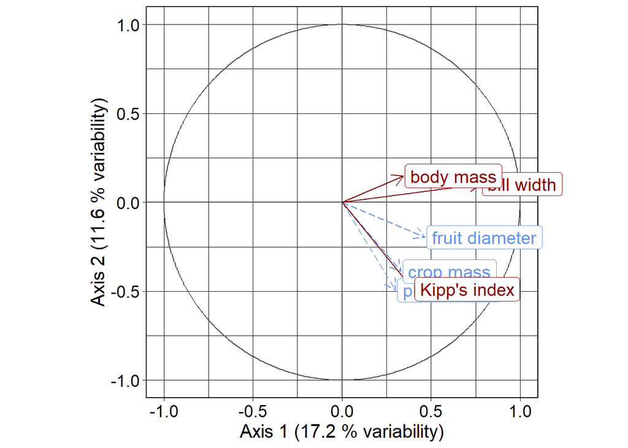

```r
rownames(corli) <- c("fruit diameter", "plant height", "crop mass")
rownames(corco) <- c("Kipp's index", "bill width", "body mass")

txtsize <- 15
plot_corcircle(cor = corli,
               col = params$colli,
               cor2 = corco,
               lty = "longdash",
               lty2 = "solid",
               col2 = params$colco,
               labsize = 5,
               eig = ca$eig) +
  theme(axis.title = element_text(size = txtsize),
        axis.text = element_text(size = txtsize*0.9),
        plot.background = element_rect(fill = "transparent", color = NA))
```

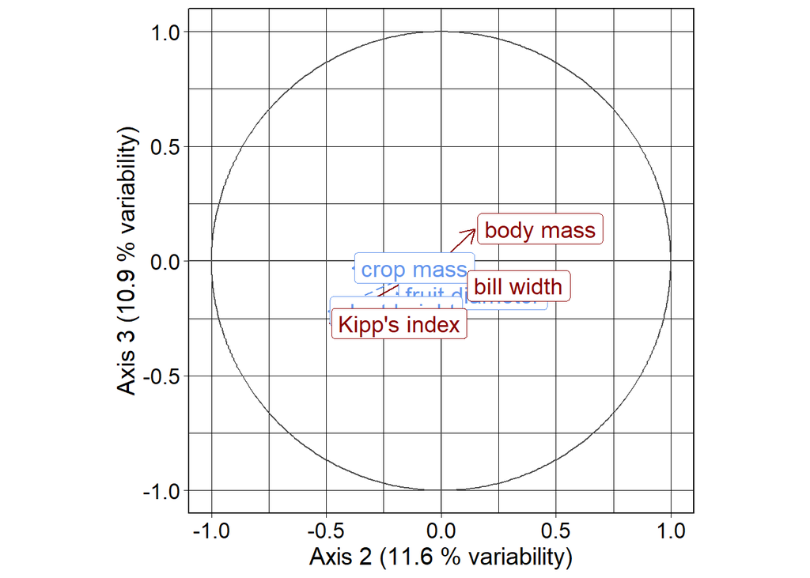

```r
ggsave(file.path(figures_path, "corcircle.svg"),
       width = 15, height = 13, units = "cm")

plot_corcircle(cor = corli,
               col = params$colli,
               xax = 2, yax = 3,
               cor2 = corco,
               lty = "longdash",
               lty2 = "solid",
               col2 = params$colco,
               labsize = 5,
               eig = ca$eig) +
  theme(axis.title = element_text(size = txtsize),
        axis.text = element_text(size = txtsize*0.9),
        plot.background = element_rect(fill = "transparent", color = NA))
```

```r
corli |>
  DT::datatable() |>
  DT::formatRound(1:ncol(corli), digits = 2)
```

|  | Axis1 | Axis2 | Axis3 |
| --- | --- | --- | --- |
| fruit diameter | 0.4653957482404856 | -0.1959764067254523 | -0.1463790048244662 |
| plant height | 0.3009069892389932 | -0.4939135251106905 | -0.2203274520199009 |
| crop mass | 0.3318929745648166 | -0.388241196864705 | -0.02965397636077677 |

```r
corco |>
  DT::datatable() |>
  DT::formatRound(1:ncol(corco), digits = 2)
```

|  | Comp1 | Comp2 | Comp3 |
| --- | --- | --- | --- |
| Kipp's index | 0.397839957819539 | -0.4878033237237958 | -0.271947111951875 |
| bill width | 0.7774111305672132 | 0.1032351559186886 | -0.1074982266229663 |
| body mass | 0.3433212798448485 | 0.148526900843464 | 0.1405020306926778 |

## Linear model with residuals

In this section, we construct linear models to predict the residuals of the regression of multivariate coordinates on known species traits. The aim is to look for a missing trait by examining the relationship between residuals and multivariate coordinates.

### Plants (rows)

We first construct the linear model predicting plants CA coordinates from their traits.

```r
lm_li <- apply(ca$li, MARGIN = 2,
               function(li) lm(li ~ plant_traits$meanHeight + plant_traits$CropMass + plant_traits$meanD1))

names(lm_li) <- paste0("Ax", 1:length(lm_li))

lapply(lm_li, summary)
```

```
$Ax1

Call:
lm(formula = li ~ plant_traits$meanHeight + plant_traits$CropMass +
    plant_traits$meanD1)

Residuals:
    Min      1Q  Median      3Q     Max
-4.2745 -1.2198 -0.3298  0.3438  5.3451

Coefficients:
                          Estimate Std. Error t value Pr(>|t|)
(Intercept)             -1.6364528  1.1618793  -1.408   0.1676
plant_traits$meanHeight  0.1267155  0.1265614   1.001   0.3234
plant_traits$CropMass   -0.0002272  0.0003218  -0.706   0.4847
plant_traits$meanD1      0.2932961  0.1257258   2.333   0.0254 *
---
Signif. codes:  0 '***' 0.001 '**' 0.01 '*' 0.05 '.' 0.1 ' ' 1

Residual standard error: 2.093 on 36 degrees of freedom
Multiple R-squared:  0.2388,    Adjusted R-squared:  0.1754
F-statistic: 3.765 on 3 and 36 DF,  p-value: 0.01895


$Ax2

Call:
lm(formula = li ~ plant_traits$meanHeight + plant_traits$CropMass +
    plant_traits$meanD1)

Residuals:
    Min      1Q  Median      3Q     Max
-1.6708 -0.7660 -0.2094  0.3716  4.1495

Coefficients:
                          Estimate Std. Error t value Pr(>|t|)
(Intercept)              1.3079644  0.6397991   2.044   0.0483 *
plant_traits$meanHeight -0.1506873  0.0696922  -2.162   0.0373 *
plant_traits$CropMass   -0.0001924  0.0001772  -1.086   0.2848
plant_traits$meanD1      0.0598534  0.0692320   0.865   0.3930
```

[output cut: 15 more lines]

```
    Min      1Q  Median      3Q     Max
-2.3713 -0.8794 -0.2794  0.6769  4.8751

Coefficients:
                          Estimate Std. Error t value Pr(>|t|)
(Intercept)              1.8489504  0.7363341   2.511   0.0167 *
plant_traits$meanHeight -0.1424334  0.0802076  -1.776   0.0842 .
plant_traits$CropMass    0.0003261  0.0002039   1.599   0.1186
plant_traits$meanD1     -0.1084142  0.0796780  -1.361   0.1821
---
Signif. codes:  0 '***' 0.001 '**' 0.01 '*' 0.05 '.' 0.1 ' ' 1

Residual standard error: 1.326 on 36 degrees of freedom
Multiple R-squared:  0.1145,    Adjusted R-squared:  0.04072
F-statistic: 1.552 on 3 and 36 DF,  p-value: 0.2179
```

Then, we plot the relationship between CA coordinates and the residuals of these models.

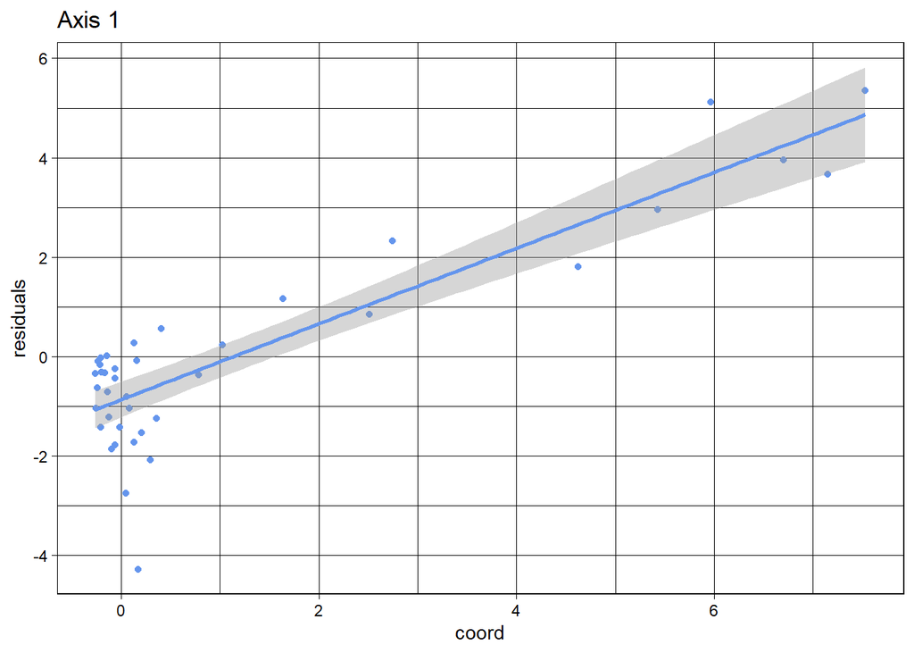

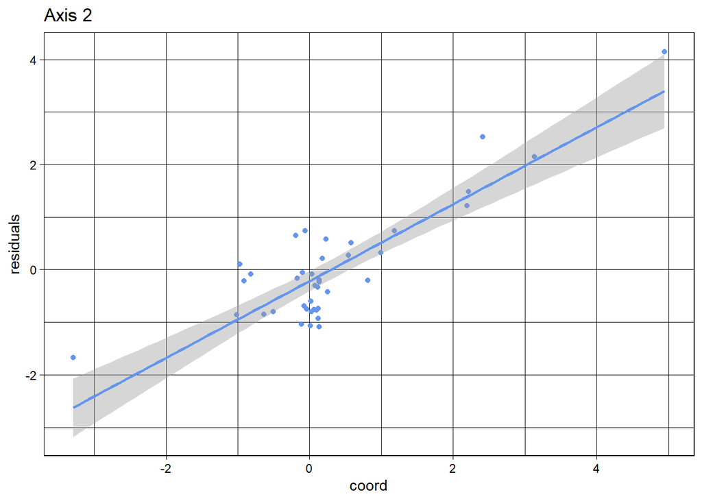

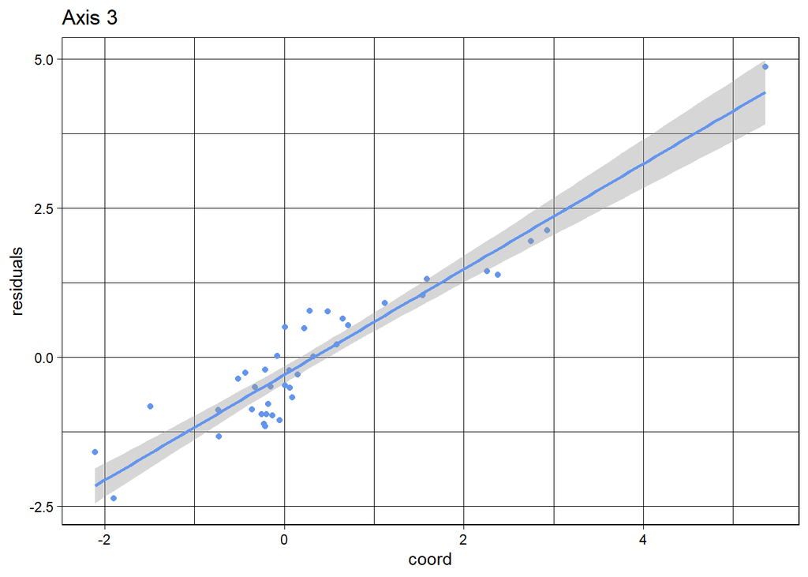

```r
res_list <- lapply(seq_along(lm_li),
                 function(i) data.frame(residuals = residuals(lm_li[[i]]), coord = ca$li[, i]))

for (i in 1:length(res_list)) {
  dfi <- res_list[[i]]

  gp <- ggplot(dfi, aes(x = coord, y = residuals)) +
    geom_point(col = params$colli) +
    geom_smooth(method = "lm", col = params$colli) +
    theme_linedraw() +
    ggtitle(paste("Axis", i))
  print(gp)
}
```

### Birds (columns)

We do the same for birds.

```r
lm_co <- apply(ca$co, MARGIN = 2,
               function(co) lm(co ~ animal_traits$Bodymass + animal_traits$BillWidth + animal_traits$KippsIndex))

names(lm_co) <- paste0("Ax", 1:length(lm_co))

lapply(lm_co, summary)
```

```
$Ax1

Call:
lm(formula = co ~ animal_traits$Bodymass + animal_traits$BillWidth +
    animal_traits$KippsIndex)

Residuals:
    Min      1Q  Median      3Q     Max
-2.8305 -0.4059 -0.0376  0.3589  4.0612

Coefficients:
                          Estimate Std. Error t value Pr(>|t|)
(Intercept)              -4.187964   0.558502  -7.499 1.12e-09 ***
animal_traits$Bodymass   -0.002276   0.001405  -1.620  0.11169
animal_traits$BillWidth   0.323581   0.039214   8.252 7.90e-11 ***
animal_traits$KippsIndex  7.605599   2.272965   3.346  0.00158 **
---
Signif. codes:  0 '***' 0.001 '**' 0.01 '*' 0.05 '.' 0.1 ' ' 1

Residual standard error: 1.036 on 49 degrees of freedom
Multiple R-squared:  0.7033,    Adjusted R-squared:  0.6851
F-statistic: 38.71 on 3 and 49 DF,  p-value: 5.669e-13


$Ax2

Call:
lm(formula = co ~ animal_traits$Bodymass + animal_traits$BillWidth +
    animal_traits$KippsIndex)

Residuals:
    Min      1Q  Median      3Q     Max
-2.0904 -0.4652 -0.0623  0.2344  3.5515

Coefficients:
                           Estimate Std. Error t value Pr(>|t|)
(Intercept)               1.6291476  0.5139784   3.170 0.002630 **
animal_traits$Bodymass    0.0001647  0.0012931   0.127 0.899161
animal_traits$BillWidth   0.0372378  0.0360882   1.032 0.307206
animal_traits$KippsIndex -8.5095565  2.0917654  -4.068 0.000172 ***
```

[output cut: 15 more lines]

```
    Min      1Q  Median      3Q     Max
-1.7002 -0.4934 -0.3312  0.2064  3.9726

Coefficients:
                          Estimate Std. Error t value Pr(>|t|)
(Intercept)               1.476814   0.554260   2.664   0.0104 *
animal_traits$Bodymass    0.002303   0.001394   1.652   0.1050
animal_traits$BillWidth  -0.056295   0.038916  -1.447   0.1544
animal_traits$KippsIndex -3.628446   2.255700  -1.609   0.1141
---
Signif. codes:  0 '***' 0.001 '**' 0.01 '*' 0.05 '.' 0.1 ' ' 1

Residual standard error: 1.028 on 49 degrees of freedom
Multiple R-squared:  0.1273,    Adjusted R-squared:  0.07385
F-statistic: 2.382 on 3 and 49 DF,  p-value: 0.08075
```

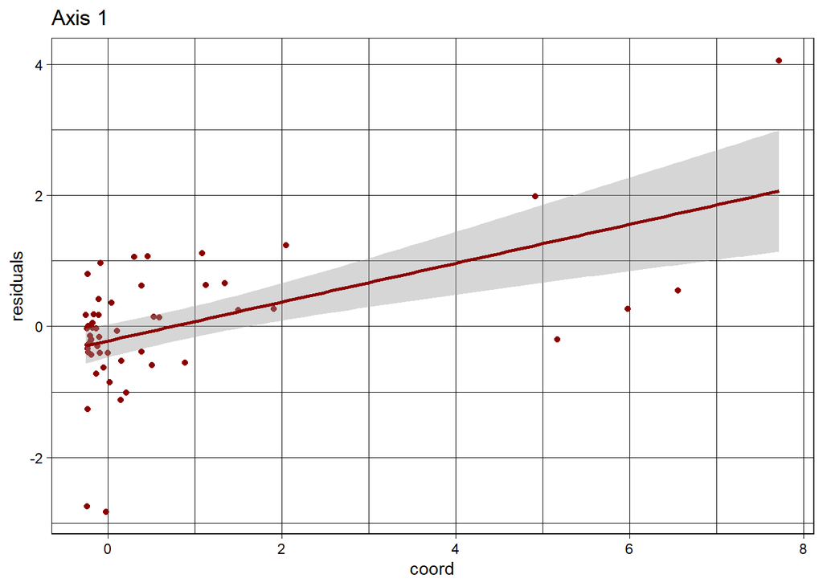

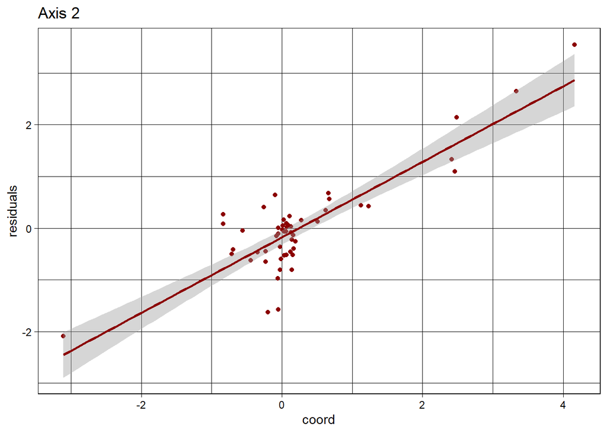

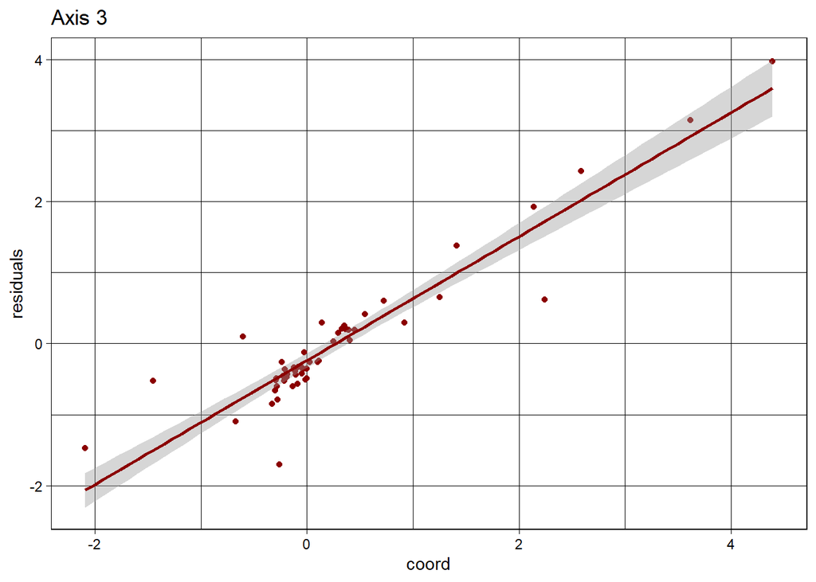

```r
res_list <- lapply(seq_along(lm_co),
                 function(i) data.frame(residuals = residuals(lm_co[[i]]), coord = ca$co[, i]))

for (i in 1:length(res_list)) {
  dfi <- res_list[[i]]

  gp <- ggplot(dfi, aes(x = coord, y = residuals)) +
    geom_point(col = params$colco) +
    geom_smooth(method = "lm", col = params$colco) +
    theme_linedraw() +
    ggtitle(paste("Axis", i))
  print(gp)
}
```

## References

Dam, Alje van, Mark Dekker, Ignacio Morales-Castilla, Miguel á. Rodríguez, David Wichmann, and Mara Baudena. 2021. “Correspondence Analysis, Spectral Clustering and Graph Embedding: Applications to Ecology and Economic Complexity.” *Scientific Reports* 11 (1): 8926. https://doi.org/10.1038/s41598-021-87971-9.

Dehling, D. Matthias, Irene M. A. Bender, Pedro G. Blendinger, Marcia C. Muñoz, Marta Quitián, Francisco Saavedra, Vinicio Santillán, Katrin Böhning-Gaese, Eike-Lena Neuschulz, and Matthias Schleuning. 2021. “ANDEAN Frugivory: Data on Plantbird Interactions and Functional Traits of Plant and Bird Species from Montane Forests Along the Andes.” https://doi.org/10.5061/DRYAD.WM37PVMN5.

Thioulouse, Jean, and Daniel Chessel. 1992. “A Method for Reciprocal Scaling of Species Tolerance and Sample Diversity.” *Ecology* 73 (2): 670–80. https://doi.org/10.2307/1940773.